# Сравнение эффективности правил диспетчеизации заказов

```r
knitr::opts_chunk$set(dev = 'png', warning = FALSE)
# выбор формата для графиков и отключение жалоб на русские шрифты на графиках
options(digits = 4) # Количество значащих цифр при выводе
suppressMessages(library(readr))
suppressMessages(library(tidyverse))
suppressMessages(library(ggplot2))
```

## Постановка задачи

**Общая эффективность оборудования** (OEE — Overall Equipment Effectiveness) – это показатель, который отражает степень эффективности использования оборудования. Он позволяет выяснить, насколько используется потенциал оборудования в реальной работе и помогает выяснить причины потерь, снижающих эффективность. Для расчета ОЕЕ необходимо перемножить следующие показатели: **производительность**, **готовность оборудования** и **качество**.

Эти показатели рассчитываются следующим образом:

- **Готовность** = Машинное время / Чистое рабочее время
- **Производительность** = Текущая выработка / Запланированная выработка
- **Качество** = Количество качественных изделий / Текущая выработка

Произведение этих элементов умножают на 100, чтобы получить результат в процентах:

ОЕЕ = Готовность x Производительность x Качество х 100

На рисунке показано, как различные потери снижают общую эффективность оборудования.

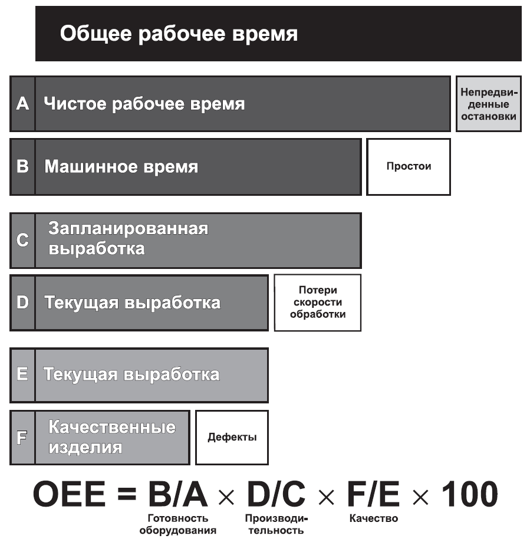

В этом задании вы исследуете, как различные правила диспетчеризации заказов влияют на коэффициент общей эффективности прокатного стана на производстве стальных труб. Данные получены методом имитационного моделирования производства.

На рисунке показана схема производственных участков.

[figure not shown]

В цехе расположены несколько производственных участков - прокатный стан, два участка отделки (О1 и О2), участок термообработки (ТО) и буферный склад.

Цех выпускает 4 вида продукции:

- черные трубы (без отделки и термообработки, сразу после сварки на стане)
- трубы с отделкой (например, нанесение покрытия или нарезка резьбы)
- трубы с термообработкой (термообработка улучшает качество, снижая остаточные напряжения в металле)
- трубы с отделкой и термообработкой

Завод получает от клиентов заказы, а планировщики и диспетчер цеха определяют какими партиями и в какой последовательности надо запускать заказы в производство.